# Situación Sector Aéreo

Diciembre de 2020

## *Indice*

1. Introducción
2. Evolución Precios del Sector
3. Evolución Precios por Empresa
4. Gráficos Lineal y Dinámico
5. Gráficas de Velas de American Airlines
6. Mapa Trayectorias Europeas de United Airlines
7. Conclusión

## *Introducción*

En el siguiente trabajo se relacionara el mercado bursátil con el sector aéreo, de forma más concreta se hablará de la evolución de los precios de las acciones de cinco grandes aerolíneas a lo largo de los últimos 5 años.

Se podrá observar, cómo se comparan varias empresas aéreas en distintos continentes y cómo se han visto influido los precios de sus acciones por diferentes shocks en estos años.

[figure not shown]

## Sector Aéreo

## *Evolución Precios del Sector*

En este gráfico se puede observar los precios de las acciones de las 5 aerolíneas: American Airlines, Air France, Lufthansa, Ryanair y United Airlines.

- 2017-2018 auge en el valor de cotización
- Finales 2019 y adelante, caida relevante (Pandemia COVID19)

[figure not shown]

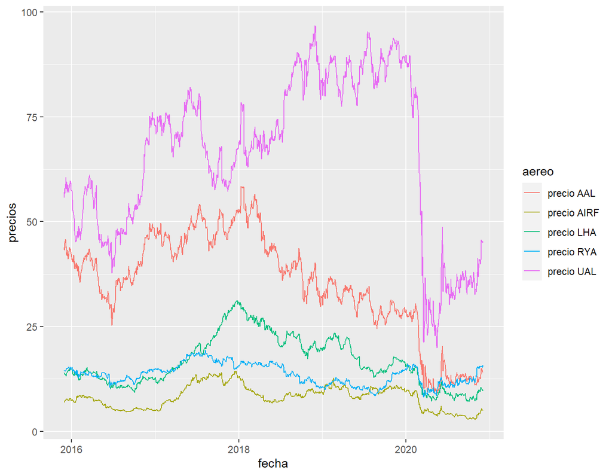

## *Evolución Precios por Empresa*

En este caso, se puede observar de manera más detallada la variación que ha tenido cada compañía aérea a lo largo del tiempo. Se separó de la gráfica conjunta de las 5 aerolíneas a una gráfica por cada empresa.

Ryanair ha sido una de las pocas empresas áreas que se ha recuperado después de la crisis

United Airlines y American Airlines que tuvieron las mayores caídas de los precios en relación a lo demás

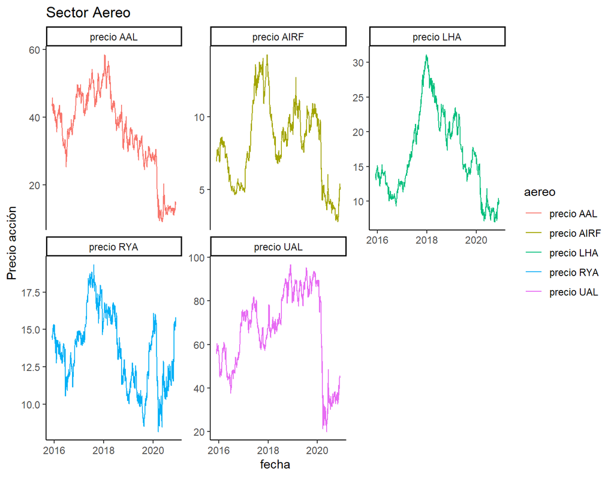

## *Gráfico Dinámico*

[figure not shown]

## *Gráficas de Velas de American Airlines*

```
#> [1] "AAL"
```

[interactive chart not shown]

## *Mapa Trayectorias Europeas de United Airlines*

Se puede observar en este mapa las rutas de United Airlines hacia el continente europeo y destacar las principales ciudades HUB las cuales son Washington DC (Capital de los Estados Unidos) y New York (La ciudad sede del gran centro financiero del país).

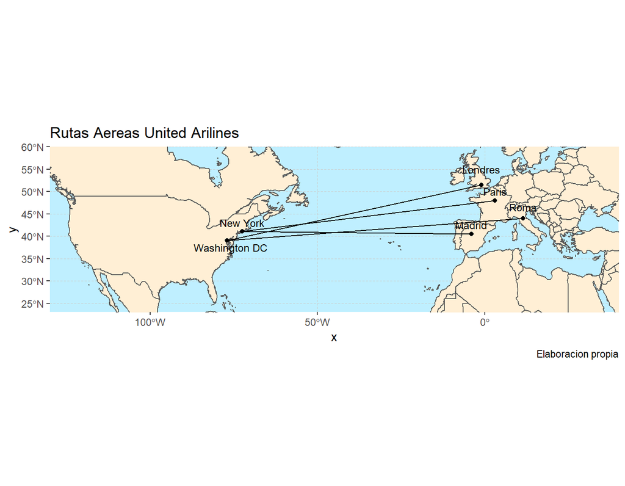

## *Conclusión*

Por un lado, hemos podido comprobar que las aerolíneas pertenecen a un sector muy volátil y por ello, se han visto gravemente perjudicadas hasta el punto de tener que ser rescatadas por los gobiernos para no entrar en quiebra.

Por otro lado, las empresas han comprobado(forzadamente) a causa del CODVID-19 que el teletrabajo es una forma de reducir costes totales. A raíz de esto, podríamos decir que ha marcado un antes y un después en la visión empresarial. Se contempla una gran incertidumbre a corto plazo.